# Fourth Week: Hypothesis Testing

TIMSS Analysis

Benyamin Jami al ahmadi 94105282

2018-03-09 01:24:09

# تمرین سری چهارم: چقدر ریاضی بلدیم و چرا؟

لطفا مقاله زیر را مطالعه بفرمایید.

[چرایی رتبه ضعیف ایران در آزمون تیمز](https://goo.gl/gX8DZc)

> با استفاده از داده های ارزیابی تیمز ۲۰۱۵ ادعاهای زیر را مورد ارزیابی قراردهید. برای هر سوال علاوه بر استدلال آماری که در غالب آزمون فرض تعریف می شود از تصویرسازی مناسب باهر دو ابزار ggplot2 و highcharter استفاده نمایید. به دلخواه به هفت گزاره از موارد زیر پاسخ دهید.

۱. میران رضایت معلمان در پیشرفت تحصیلی دانش آموزان موثر است.

```r
merge(studetgrade ,
      btg %>% mutate(feel = btdgtjs) %>% select(idcntry,idschool,idtealin,feel),
      by = c('idtealin','idcntry','idschool')
      ) %>% group_by(idcntry,idschool,idstud,feel) %>% summarise(grade = mean(grade))  -> ans1

summary(aov(grade~as.factor(feel),data = ans1))
```

```
##                     Df    Sum Sq Mean Sq F value Pr(>F)
## as.factor(feel)      2 4.757e+06 2378617   209.3 <2e-16 ***
## Residuals       265512 3.018e+09   11367
## ---
## Signif. codes:  0 '***' 0.001 '**' 0.01 '*' 0.05 '.' 0.1 ' ' 1
## 17034 observations deleted due to missingness
```

```r
ans1 %>% select(JobSatisfaction = feel,grade) %>%  filter(!is.na(grade)) %>% group_by(JobSatisfaction) %>% summarise(avegrade = mean(grade)) %>% hchart("scatter",hcaes(x = JobSatisfaction, y = avegrade)) %>% hc_add_theme(hc_theme_db())
```

[interactive chart not shown]

```r
rm(ans1)
```

۲. والدینی که تحصیلات بیشتری دارند دارای فرزندان موفق تری می باشند.

```r
merge(studetgrade,
      bsg %>% select(parent = bsdgedup, idstud, idcntry, idschool),
      by=c("idstud", "idcntry", "idschool")) %>% filter(parent < 6) -> ans2


ans2 %>% group_by(parent) %>% summarise(grade = mean(grade)) %>% hchart("scatter",hcaes(x=parent,y=grade)) %>% hc_add_theme(hc_theme_db())
```

[interactive chart not shown]

```r
for(i in 1:4) {
  ans2 %>% filter(parent == i | parent == i + 1) %>% t.test(grade ~ parent,data = .,alt = "greater") %>% print()
}
```

```
##
##  Welch Two Sample t-test
##
## data:  grade by parent
## t = 104.25, df = 243540, p-value < 2.2e-16
## alternative hypothesis: true difference in means is greater than 0
## 95 percent confidence interval:
##  36.89971      Inf
## sample estimates:
## mean in group 1 mean in group 2
##        525.0320        487.5408
##
##
##  Welch Two Sample t-test
##
## data:  grade by parent
## t = 43.788, df = 239260, p-value < 2.2e-16
## alternative hypothesis: true difference in means is greater than 0
## 95 percent confidence interval:
##  17.18544      Inf
## sample estimates:
## mean in group 2 mean in group 3
##        487.5408        469.6846
##
##
##  Welch Two Sample t-test
##
## data:  grade by parent
## t = 99.876, df = 111920, p-value < 2.2e-16
## alternative hypothesis: true difference in means is greater than 0
## 95 percent confidence interval:
##  49.28901      Inf
## sample estimates:
## mean in group 3 mean in group 4
##        469.6846        419.5702
##
##
##  Welch Two Sample t-test
##
## data:  grade by parent
## t = 28.744, df = 76549, p-value < 2.2e-16
## alternative hypothesis: true difference in means is greater than 0
## 95 percent confidence interval:
##  17.1042     Inf
## sample estimates:
## mean in group 4 mean in group 5
##        419.5702        401.4278
```

```r
rm(ans2)
```

۳. امکانات رفاهی در خانه موجب پیشرفت تحصیلی می گردد.

```r
merge(bsg %>% mutate(Home = bsbgher) %>% select(idcntry,idschool,idstud,Home) ,
      bst %>% mutate(grade = rowSums(.[25:29])/5) %>% group_by(idcntry,idschool,idstud,idtealin) %>%summarise(grade = mean(grade)),
      by = c("idcntry","idstud","idschool"))  -> ans3

cor.test(ans3$grade,ans3$Home)
```

```
##
##  Pearson's product-moment correlation
##
## data:  ans3$grade and ans3$Home
## t = 424.72, df = 682840, p-value < 2.2e-16
## alternative hypothesis: true correlation is not equal to 0
## 95 percent confidence interval:
##  0.4552476 0.4590001
## sample estimates:
##       cor
## 0.4571259
```

```r
ans3 %>% group_by(Home) %>% summarise(grade = mean(grade)) %>% hchart("point",hcaes(Home,grade),regression=TRUE) %>% hc_add_theme(hc_theme_db())
```

[interactive chart not shown]

```r
rm(ans3)
```

۴. محیط آرام مدرسه نقش مهمی در پیشرفت تحصیلی دارد.

```r
merge(bsg %>% mutate(School = bsbgsb) %>% select(idcntry,idschool,idstud,School) ,
      studetgrade,
      by = c("idcntry","idstud","idschool"))->ans4

cor.test(ans4$grade,ans4$School)
```

```
##
##  Pearson's product-moment correlation
##
## data:  ans4$grade and ans4$School
## t = 147.77, df = 671340, p-value < 2.2e-16
## alternative hypothesis: true correlation is not equal to 0
## 95 percent confidence interval:
##  0.1751665 0.1798000
## sample estimates:
##       cor
## 0.1774842
```

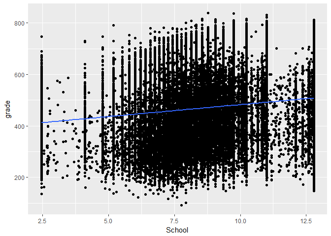

```r
ans4 %>% ggplot(aes(x = School,y = grade)) + geom_point() + geom_smooth(method = "lm")
```

```r
rm(ans4)
```

۵. معلمان با تحصیلات بالاتر یا تجربه بیشتر دانش آموزان موفق تری تربیت می کنند.

```r
merge(bst %>% mutate(grade = rowSums(.[25:100])) %>% select(idcntry,idschool,idstud,idtealin,grade) ,
      btg %>% mutate(experience = btbg01,edu = btbg04) %>% select(idcntry,idschool,idtealin,experience,edu),
      by = c('idtealin','idcntry','idschool')
) %>% group_by(idcntry,idschool,idtealin,experience,edu) %>% summarise(grade = mean(grade)) -> ans5
summary(aov(grade ~ (as.factor(experience) * as.factor(edu)),data = ans5))
```

```
##                                         Df    Sum Sq   Mean Sq F value
## as.factor(experience)                   54 3.512e+09 6.503e+07   1.782
## as.factor(edu)                           6 2.943e+10 4.904e+09 134.400
## as.factor(experience):as.factor(edu)   203 1.286e+10 6.333e+07   1.736
## Residuals                            11423 4.168e+11 3.649e+07
##                                        Pr(>F)
## as.factor(experience)                0.000376 ***
## as.factor(edu)                        < 2e-16 ***
## as.factor(experience):as.factor(edu) 6.47e-10 ***
## Residuals
## ---
## Signif. codes:  0 '***' 0.001 '**' 0.01 '*' 0.05 '.' 0.1 ' ' 1
## 1611 observations deleted due to missingness
```

```r
ans5 %>% group_by(edu) %>% summarise(avegrade = mean(grade)) %>% hchart("point",hcaes(edu,avegrade)) %>%  hc_add_theme(hc_theme_db())
```

[interactive chart not shown]

```r
ans5 %>% group_by(experience) %>% summarise(avegrade = mean(grade)) %>% hchart("point",hcaes(experience,avegrade)) %>%  hc_add_theme(hc_theme_db())
```

[interactive chart not shown]

```r
rm(ans5)
```

۶. پسران در کاربرد هندسه قوی تر هستند.

```r
tims %>% filter(content_domain == "Geometry", cognitive_domain == "Applying") %>%
  select(female = correct_ratio_per_question_female, male = correct_ratio_per_question_male) %>%
  tidyr::gather("female","male", key = "gender",value = "score") -> ans6
t.test(score ~ gender,data = ans6,alt = "greater")
```

```
##
##  Welch Two Sample t-test
##
## data:  score by gender
## t = 0.23614, df = 1493.7, p-value = 0.4067
## alternative hypothesis: true difference in means is greater than 0
## 95 percent confidence interval:
##  -0.01558772         Inf
## sample estimates:
## mean in group female   mean in group male
##            0.4112235            0.4086124
```

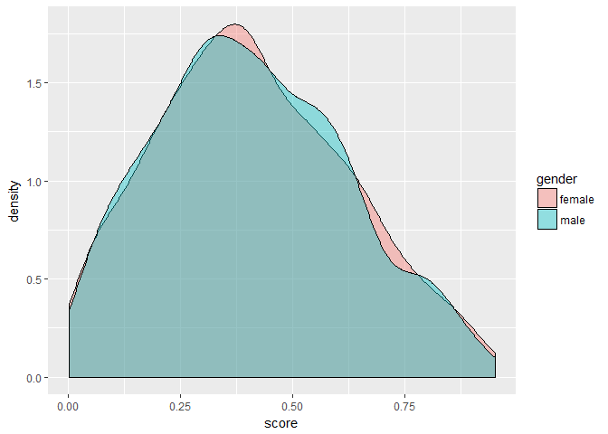

```r
ggplot(ans6,aes(x = score,fill = gender)) + geom_density(alpha = 0.4)
```

۷. تغذیه دانش آموزان نقش اساسی در یادگیری آنها دارد.

```r
merge(bsg %>% mutate(Meal = bsbg12) %>% select(idcntry,idschool,idstud,Meal) ,
      studetgrade,
      by = c("idcntry","idstud","idschool")) -> ans7
for(i in 1:3) {
  ans7 %>% filter(Meal == i | Meal == i + 1) %>% t.test(grade ~ Meal,data = .,alt = "greater") %>% print()
}
```

```
##
##  Welch Two Sample t-test
##
## data:  grade by Meal
## t = 12.055, df = 212980, p-value < 2.2e-16
## alternative hypothesis: true difference in means is greater than 0
## 95 percent confidence interval:
##  3.617986      Inf
## sample estimates:
## mean in group 1 mean in group 2
##        493.0113        488.8216
##
##
##  Welch Two Sample t-test
##
## data:  grade by Meal
## t = 84.961, df = 246130, p-value < 2.2e-16
## alternative hypothesis: true difference in means is greater than 0
## 95 percent confidence interval:
##  32.3221     Inf
## sample estimates:
## mean in group 2 mean in group 3
##        488.8216        455.8614
##
##
##  Welch Two Sample t-test
##
## data:  grade by Meal
## t = -63.603, df = 183540, p-value = 1
## alternative hypothesis: true difference in means is greater than 0
## 95 percent confidence interval:
##  -27.24808       Inf
## sample estimates:
## mean in group 3 mean in group 4
##        455.8614        482.4226
```

```r
ans7 %>% select(Breakfast = Meal,grade) %>%  filter(!is.na(grade)) %>% group_by(Breakfast) %>% summarise(avegrade = mean(grade)) %>% hchart("scatter",hcaes(x = Breakfast, y = avegrade)) %>% hc_add_theme(hc_theme_db())
```

[interactive chart not shown]

```r
rm(ans7)
```

۸. مدارس با امکانات بیشتر دارای عملکرد بهتری می باشند.

۹. علت افت تحصیلی عدم مشارکت در کلاس است.

۱۰. دانش آموزان ایرانی در استدلال قوی تر از کاربرد هستند.

سه گزاره جالب کشف کنید و ادعای خود را ثابت نمایید.

تمرین در منزل در وضعیت تحصیلی موثر است.

```r
merge(bsg %>% mutate(HW = bsdmwkhw) %>% select(idcntry,idschool,idstud,HW) ,
      studetgrade,
      by = c("idcntry","idstud","idschool")) -> ans8

summary(aov(grade~HW,data = ans8))
```

```
##                 Df    Sum Sq  Mean Sq F value Pr(>F)
## HW               1 6.914e+07 69138090    6512 <2e-16 ***
## Residuals   664192 7.052e+09    10618
## ---
## Signif. codes:  0 '***' 0.001 '**' 0.01 '*' 0.05 '.' 0.1 ' ' 1
## 30741 observations deleted due to missingness
```

```r
ans8 %>% select(Homework = HW,grade) %>%  filter(!is.na(grade)) %>% group_by(Homework) %>%
summarise(avegrade = mean(grade)) %>% hchart("scatter",hcaes(x = Homework, y = avegrade)) %>% hc_add_theme(hc_theme_db())
```

[interactive chart not shown]

```r
rm(ans8)
```

اعتماد به نفس بالا باعث رشد تحصیلی میشود.

```r
merge(bsg %>% mutate(Confident = bsbgscm) %>% select(idcntry,idschool,idstud,Confident) ,
      studetgrade,
      by = c("idcntry","idstud","idschool")) -> ans9

cor.test(ans9$grade,ans9$Confident)
```

```
##
##  Pearson's product-moment correlation
##
## data:  ans9$grade and ans9$Confident
## t = 276.57, df = 682580, p-value < 2.2e-16
## alternative hypothesis: true correlation is not equal to 0
## 95 percent confidence interval:
##  0.3153097 0.3195762
## sample estimates:
##       cor
## 0.3174446
```

```r
ans9 %>% select(Confident,grade) %>%  filter(!is.na(grade)) %>% group_by(Confident) %>%
summarise(avegrade = mean(grade)) %>% hchart("scatter",hcaes(x = Confident, y = avegrade)) %>% hc_add_theme(hc_theme_db())
```

[interactive chart not shown]

```r
rm(ans8)
```

فعالیت در خانه در پیشرفت تحصیلی موثر است.

```r
merge(bsg %>% mutate(activity = bsbg03) %>% select(idcntry,idschool,idstud,activity) ,
      studetgrade,
      by = c("idcntry","idstud","idschool")) -> ans10

summary(aov(grade~activity,data = ans10))
```

```
##                 Df    Sum Sq   Mean Sq F value Pr(>F)
## activity         1 3.224e+08 322434082   30918 <2e-16 ***
## Residuals   687403 7.169e+09     10429
## ---
## Signif. codes:  0 '***' 0.001 '**' 0.01 '*' 0.05 '.' 0.1 ' ' 1
## 7530 observations deleted due to missingness
```

```r
ans10 %>% select(activity,grade) %>%  filter(!is.na(grade)) %>% group_by(activity) %>%
summarise(avegrade = mean(grade)) %>% hchart("scatter",hcaes(x = activity, y = avegrade)) %>% hc_add_theme(hc_theme_db())
```

[interactive chart not shown]

```r
rm(ans10)
```